# 705604096_stats101a_hw3

Jade Gregory

2023-04-18

## Question 1

```r
slr <- function(beta_0, beta_1, sigma, x, rns){
  set.seed(rns)
  eps <- rnorm(length(x), 0, sigma)
  beta_0 + (beta_1 * x) + eps
}
```

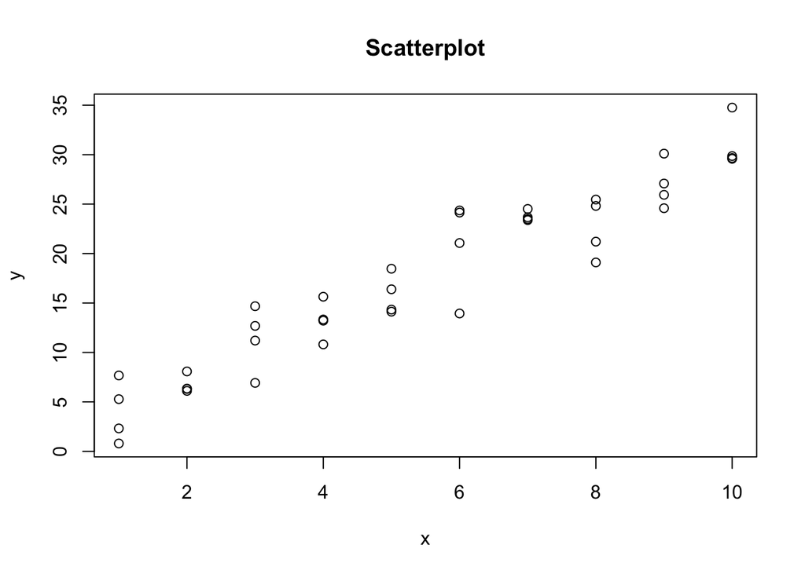

```r
x <- rep(1:10, by = .1, 4)
y <- slr(1, 3, 3, x, 123)
plot(x, y, main = "Scatterplot")
```

```r
cor(x, y)
```

```
## [1] 0.9529631
```

The correlation coefficient is 0.9529631

```r
x2 <- rep(1:10, by = .1, 4)
y2 <- slr(1, 30, 3, x2, 123)
cor(x2, y2)
```

```
## [1] 0.9995272
```

With parameters
$$\beta_0 = 1 \\ \beta_1 =
30 \\ \sigma = 3$$
we get a correlation of 0.9995272

## Question 2

```r
my_data <- read_csv('armspans2022_gender.csv')
my_data['compmother'] <- tolower(my_data$compmother)
my_data['compfather'] <- tolower(my_data$compfather)
my_data$compmother <- str_replace_all(my_data$compmother, c(" " = "_", "'" =""))
my_data$compfather <- str_replace_all(my_data$compfather, c(" " = "_", "'" =""))
my_data
```

```
## # A tibble: 46 × 5
##    height armspan is.female compmother     compfather
##     <dbl>   <dbl>     <dbl> <chr>          <chr>
##  1   74      76           0 taller         taller
##  2   65      65           0 taller         about_the_same
##  3   60      53           1 shorter        shorter
##  4   69.8    69           0 taller         about_the_same
##  5   70      72           0 taller         about_the_same
##  6   68      70.5         0 taller         shorter
##  7   64      60           0 taller         taller
##  8   68      67           0 taller         about_the_same
##  9   68      67           1 taller         shorter
## 10   63      60           1 about_the_same shorter
## # … with 36 more rows
```

When cleaning this data, I decided to make all of the elements in the columns lower case to make it easier to manipulate in the future. I also replaced spaces in between words with underscores for the same reason.

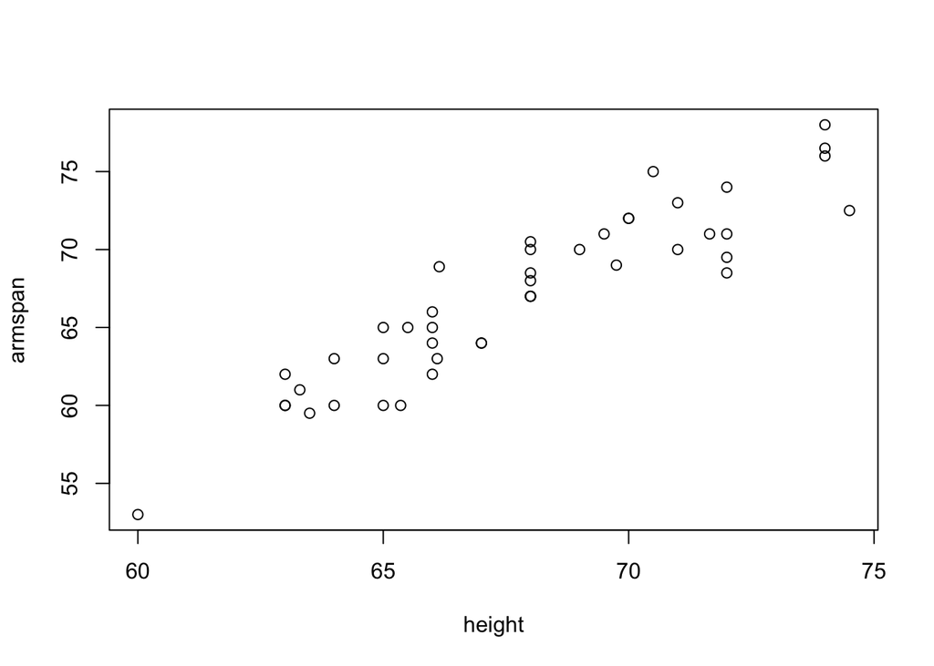

```r
plot(armspan ~ height, data = my_data )
```

We can observe a positive linear trend in this scatter plot. We can describe the strength as in between moderate and strong between the observations, since there is a clear linear pattern that is noticeable. There are not any unusual features we can discern from this scatter plot, except for the lowest value being farther from the bulk of the data but still in line with our linear pattern.

```r
plot(armspan ~ height, data = my_data )
my_lm <- lm(armspan ~ height, data = my_data)
summary(my_lm)
```

```
##
## Call:
## lm(formula = armspan ~ height, data = my_data)
##
## Residuals:
##     Min      1Q  Median      3Q     Max
## -4.4353 -1.5302  0.0369  1.4893  4.3080
##
## Coefficients:
##              Estimate Std. Error t value Pr(>|t|)
## (Intercept) -29.63530    6.22105  -4.764 2.19e-05 ***
## height        1.42459    0.09158  15.555  < 2e-16 ***
## ---
## Signif. codes:  0 '***' 0.001 '**' 0.01 '*' 0.05 '.' 0.1 ' ' 1
##
## Residual standard error: 2.135 on 43 degrees of freedom
##   (1 observation deleted due to missingness)
## Multiple R-squared:  0.8491, Adjusted R-squared:  0.8456
## F-statistic:   242 on 1 and 43 DF,  p-value: < 2.2e-16
```

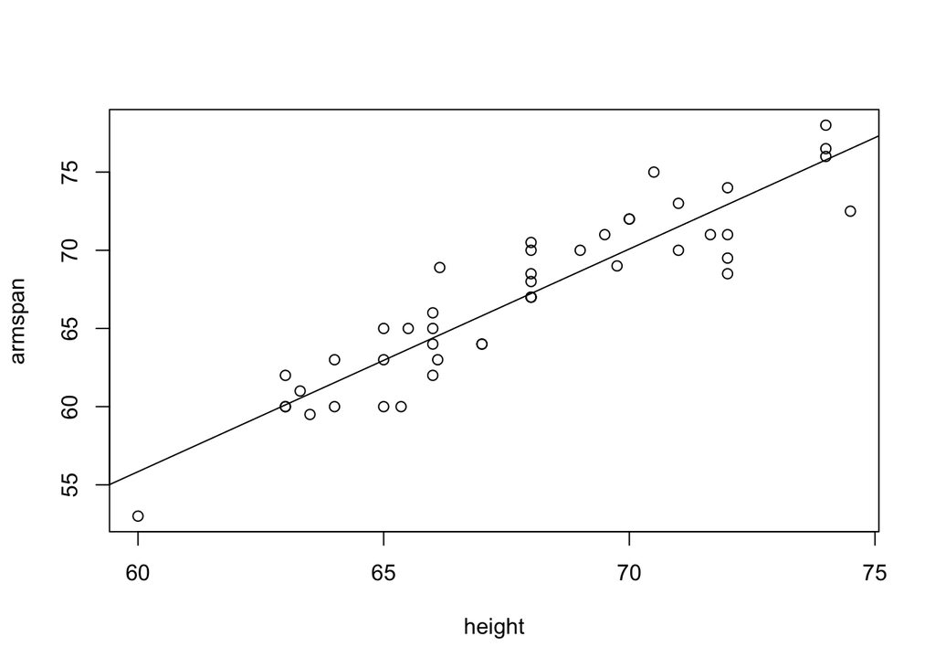

```r
abline(my_lm)
```

The equation for our estimated line is
$$\hat{y}_i = -29.63530 + 1.42459x_i$$

```r
my_func <- function(x){
  -29.6353 + 1.42459 * x
}
my_func(63)
```

```
## [1] 60.11387
```

```r
residual <- 61 - my_func(63)
residual
```

```
## [1] 0.88613
```

Based on our model, the predicted arm span for my height is 60.11387 inches. The residual is 0.88613 inches.

```r
my_func(76)
```

```
## [1] 78.63354
```

```r
residual2 <- 79 - my_func(76)
residual2
```

```
## [1] 0.36646
```

No, this does not seem unusual as the residual is relatively small.

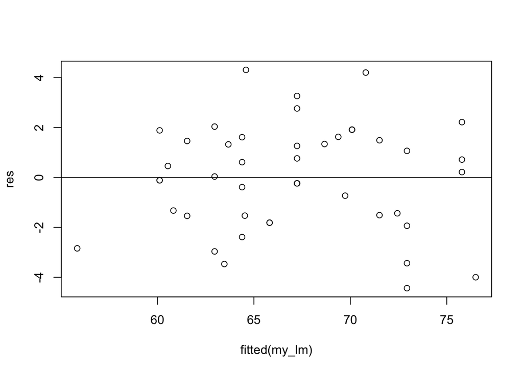

```r
res <- resid(my_lm)
plot(fitted(my_lm), res)
abline(0,0)
```

## Question 3

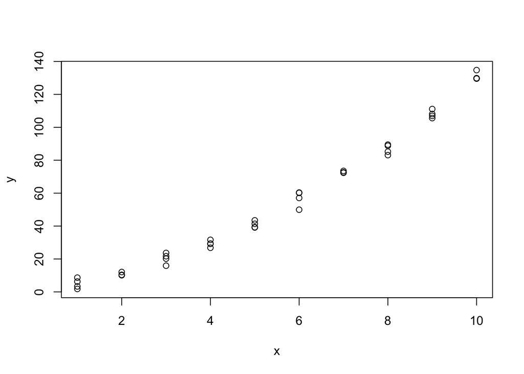

```r
quad_func <- function(a, b, c, sigma, x = rep(1:10,by=.1,4), random.seed){
  set.seed(random.seed)
  a + (b * x) + (c * (x^2)) + rnorm(length(x), 0, sigma)
}
x <- rep(1:10,by=.1,4)
y <- quad_func(1, 3, 1, 3, x, 123)
plot(x, y)
```

b)

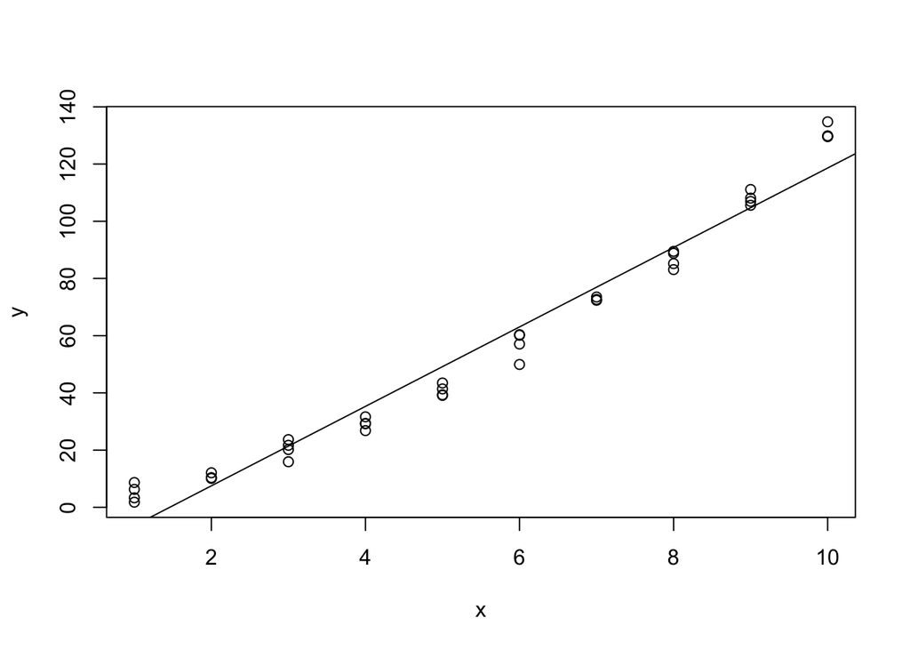

```r
plot(x, y)
my_lm3 <- lm(y ~ x)
abline(my_lm3)
```

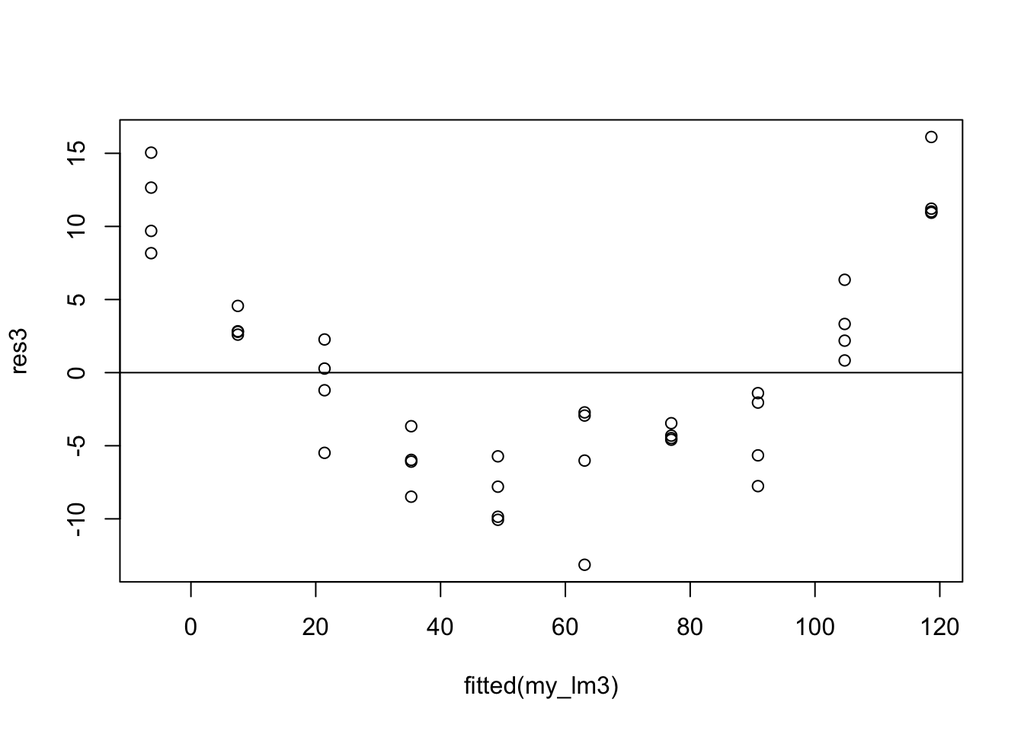

```r
res3 <- resid(my_lm3)
plot(fitted(my_lm3), res3)
abline(0,0)
```

In this residual plot, we can observe a quadratic shape or a parabola appear.

3. If the residual plot shows features like parabolic shapes, we can conclude that the trend is non-linear.

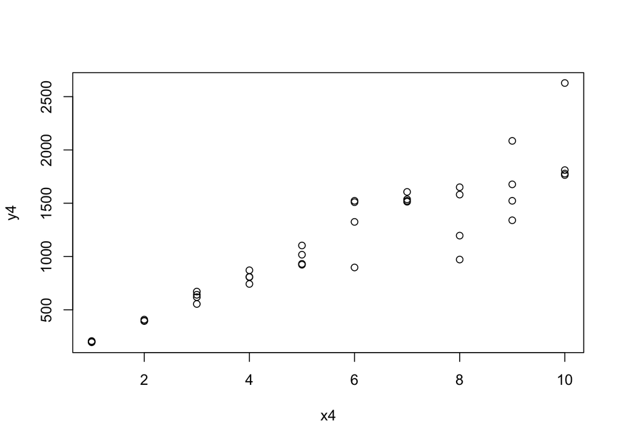

```r
my_nl_func <- function(a, b, x, sigma, random.seed){
  set.seed(random.seed)
  a + (b * x) + rnorm(length(x), 0, (sigma * (x^2)))
}
x4 <- rep(1:10, by = .1, 4)
y4 <- my_nl_func(1, 200, x4, 5, 123)
plot(y4 ~ x4)
```

e)

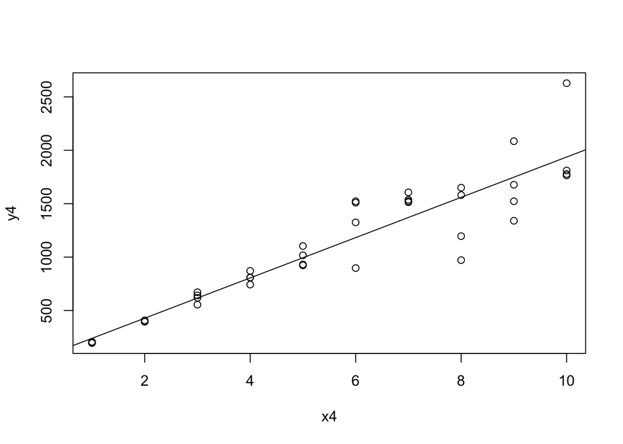

```r
plot(x4, y4)
my_lm4 <- lm(y4 ~ x4)
abline(my_lm4)
```

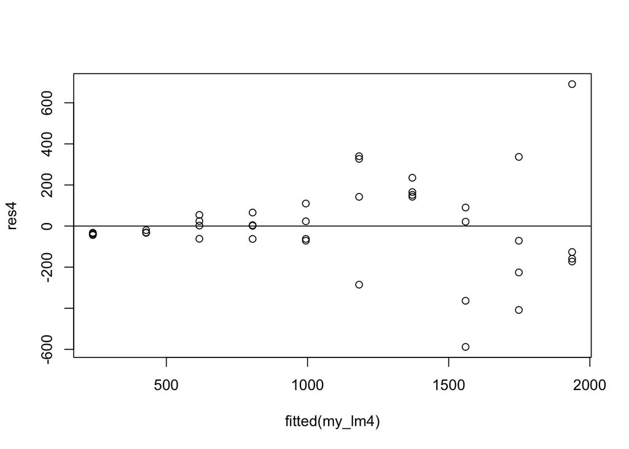

```r
res4 <- resid(my_lm4)
plot(fitted(my_lm4), res4)
abline(0,0)
```

The cone shape of the residual plot indicates that the standard deviation increases as x increases, and therefore the constant standard deviation assumption is violated.

## Question 4

```r
atus <- read.csv('atus.csv')
atus1 <- subset(atus, homework > 0)
head(atus1)
```

```
##          caseid        state age gender             citizen  marital_stat
## 24  2.01201e+13      Florida  20   Male Native, Born in USA Never married
## 32  2.01201e+13    Wisconsin  67 Female Native, Born in USA Never married
## 50  2.01201e+13      Florida  18   Male Native, Born in USA Never married
## 65  2.01201e+13     New York  43 Female Native, Born in USA       Married
## 103 2.01201e+13 Pennsylvania  30   Male Native, Born in USA Never married
## 105 2.01201e+13  Connecticut  20 Female Native, Born in USA Never married
##         veteran active_armedforces          emp_status multi_jobs
## 24  Non-Veteran                 No Unemployed, Looking  No answer
## 32      Veteran                 No  Not in labor force  No answer
## 50  Non-Veteran                 No            Employed         No
## 65  Non-Veteran                 No            Employed         No
## 103 Non-Veteran                 No            Employed         No
## 105 Non-Veteran                 No  Not in labor force  No answer
##                        work_class   retired fulltime_emp hours_worked
```

[output cut: 41 more lines]

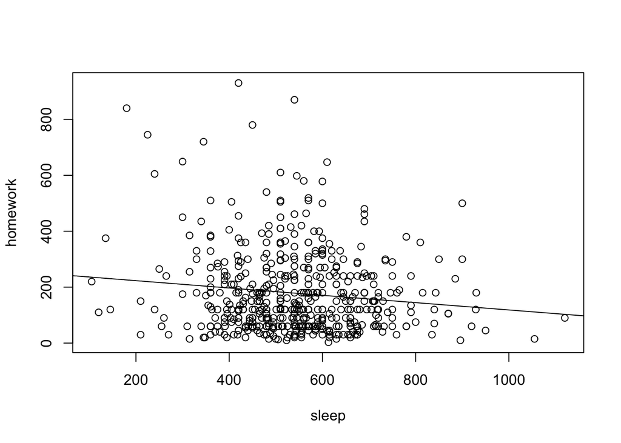

```r
plot(homework ~ sleep, data = atus1)
my_lm_2 <- lm(homework ~ sleep, data = atus1)
abline(my_lm_2)
```

The linear model is not an appropriate model to describe the relationship between sleep times and homework times.

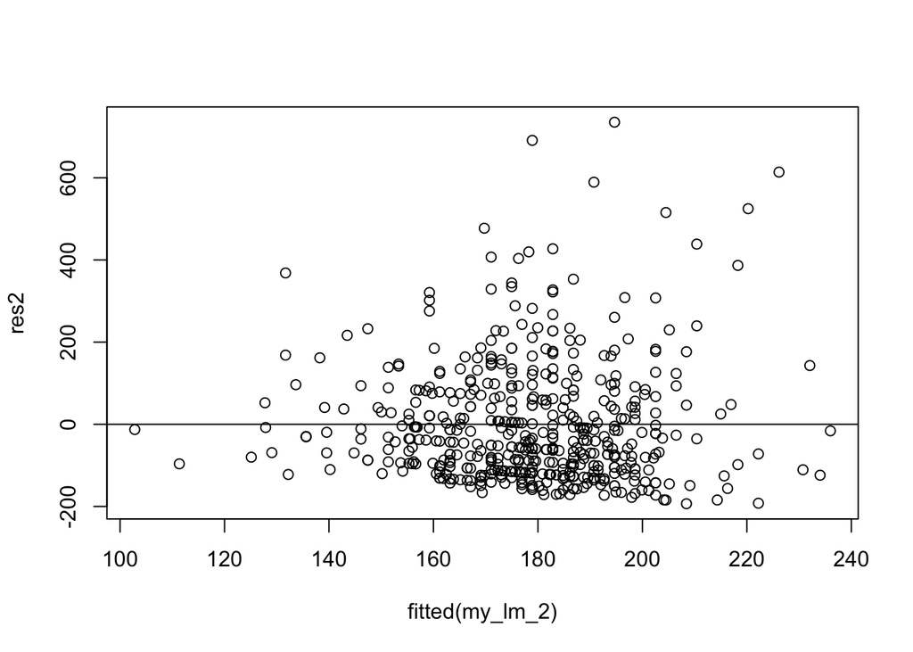

```r
res2 <- resid(my_lm_2)
plot(fitted(my_lm_2), res2)
abline(0,0)
```

From the residual plot, we can tell that this data is negatively correlated. We can also tell that since it is not evenly distributed, a linear model would not be the best model to approximate this data.

## Question 5

```r
t.test(atus1$household_chores ~ atus1$gender, alternative = "greater", conf.level = 0.95)
```

```
##
##  Welch Two Sample t-test
##
## data:  atus1$household_chores by atus1$gender
## t = 6.3978, df = 446.68, p-value = 1.993e-10
## alternative hypothesis: true difference in means between group Female and group Male is greater than 0
## 95 percent confidence interval:
##  34.62905      Inf
## sample estimates:
## mean in group Female   mean in group Male
##             77.17730             30.53052
```

2. We must assume the population distribution is normal or our sample size is sufficiently large to provide us with a good approximation. We can assume that these conditions are met because we have a large sample size observed in our data frame, which is sufficient.